# M2 Data Analysis: Descriptive Statistics

Matthew Ragoza 9/18/2021

- Obstetrics and Periodontal Therapy (OPT) study dataset
  - Treatment group
  - Infant birthweight
  - Age of pregnant individual at baseline
  - Preterm birth
  - Maximum and minimum infant birthweight
  - Relationship between preterm birth and treatment group
  - Relationship between preterm birth and age of pregnant individual
  - Relationship between age of pregnant individual and infant birthweight

## Obstetrics and Periodontal Therapy (OPT) study dataset

```r
load('OPT.RData')
```

### Treatment group

Treatment group is categorical, so its distribution is shown in Figure 1 as a bar chart, and the frequency and relative frequency of each treatment group category are listed in Table 1. As expected based on the study description, there were 410 pregnant individuals in the control group (49.8%) and 413 in the treatment group (50.2%), amounting to a total of N=823.

**Figure 1.** Visualization of treatment group

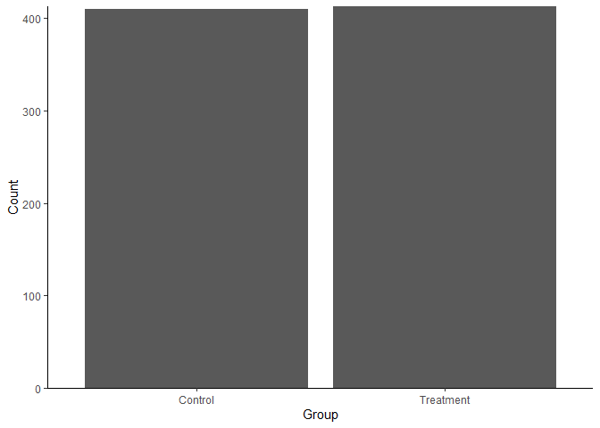

```r
ggplot(opt %>%
    drop_na(Group),
    aes(x=Group)
) + geom_bar() + theme_classic() + ylab('Count') +
    scale_y_continuous(expand = c(0, 0), limits = c(0, NA))
```

**Table 1.** Numerical summary of treatment group

```r
kable(opt %>%
    group_by(Group) %>%
    summarize(Count=n()) %>%
    mutate(Percent=Count/sum(Count)*100) %>%
    adorn_totals()
)
```

| Group | Count | Percent |
| --- | --- | --- |
| Control | 410 | 49.81774 |
| Treatment | 413 | 50.18226 |
| Total | 823 | 100.00000 |

### Infant birthweight

The next variable of interest is infant birthweight in grams, which is quantitative. Therefore, it is visualized in Figure 2 as a histogram and numerically summarized in Table 2 using measures of center and spread. The distribution of birthweight is unimodal, and the fact that the mean (3248) is less than the median (3280) suggests that the distribution is slightly left-skewed. This is also supported by the longer left tail than right tail seen in Figure 2. As such, the median is a better estimate of central tendency than the mean, which is biased towards the low outliers. Furthermore, the standard deviation is 580 and the IQR is 595.

**Figure 2.** Visualization of infant birthweight

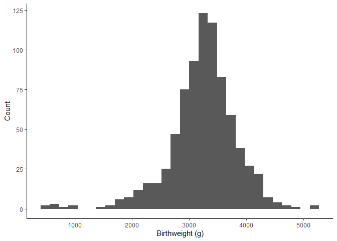

```r
ggplot(opt %>%
    drop_na(Birthweight),
    aes(x=Birthweight)
) + geom_histogram() + theme_classic() + xlab('Birthweight (g)') + ylab('Count')
```

**Table 2.** Numerical summary of infant birthweight

```r
kable(opt %>%
    summarize(
        N=n(),
        N_NA=sum(is.na(Birthweight)),
        Mean=mean(Birthweight, na.rm=TRUE),
        SD=sd(Birthweight, na.rm=TRUE),
        Min=min(Birthweight, na.rm=TRUE),
        Pct_25=quantile(Birthweight, 0.25, na.rm=TRUE),
        Median=median(Birthweight, na.rm=TRUE),
        Pct_75=quantile(Birthweight, 0.75, na.rm=TRUE),
        Max=max(Birthweight, na.rm=TRUE),
        IQR=quantile(Birthweight, 0.75, na.rm=TRUE)-quantile(Birthweight, 0.25, na.rm=TRUE),
        Range=max(Birthweight, na.rm=TRUE)-min(Birthweight, na.rm=TRUE),
    )
)
```

| N | N_NA | Mean | SD | Min | Pct_25 | Median | Pct_75 | Max | IQR | Range |
| --- | --- | --- | --- | --- | --- | --- | --- | --- | --- | --- |
| 823 | 30 | 3248.288 | 579.9857 | 450 | 2985 | 3280 | 3580 | 5160 | 595 | 4710 |

### Age of pregnant individual at baseline

Next we examine the age of the pregnant individual in years at baseline. This variable is also quantitative, so its distribution is seen in Figure 3 as a histogram and summarized in Table 3 using measures of center and spread. This time, viewing the shape in Figure 3 reveals a unimodal right-skewed distribution, which is also indicated by the mean (26) being greater than the median (25). In addition, the standard deviation of birthweight is 5.6 and the IQR is 8.

**Figure 3.** Visualization of age of pregnant individual at baseline

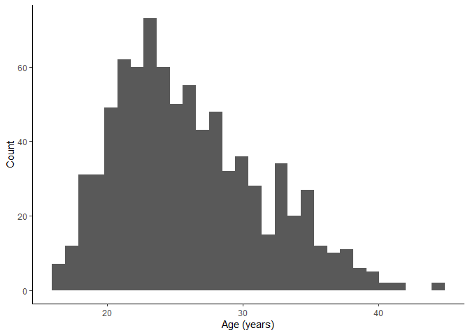

```r
ggplot(opt %>%
    drop_na(Age),
    aes(x=Age)
) + geom_histogram() + theme_classic() + xlab('Age (years)') + ylab('Count')
```

**Table 3.** Numerical summary of age of pregnant individual at baseline

```r
kable(opt %>%
    summarize(
        N=n(),
        Mean=mean(Age, na.rm=TRUE),
        SD=sd(Age, na.rm=TRUE),
        Min=min(Age, na.rm=TRUE),
        Pct_25=quantile(Age, 0.25, na.rm=TRUE),
        Median=median(Age, na.rm=TRUE),
        Pct_75=quantile(Age, 0.75, na.rm=TRUE),
        Max=max(Age, na.rm=TRUE),
        IQR=quantile(Age, 0.75, na.rm=TRUE)-quantile(Age, 0.25, na.rm=TRUE),
        Range=max(Age, na.rm=TRUE)-min(Age, na.rm=TRUE),
    )
)
```

| N | Mean | SD | Min | Pct_25 | Median | Pct_75 | Max | IQR | Range |
| --- | --- | --- | --- | --- | --- | --- | --- | --- | --- |
| 823 | 25.97813 | 5.565973 | 16 | 22 | 25 | 30 | 44 | 8 | 28 |

### Preterm birth

The fourth variable to analyze is preterm birth, which is coded categorically. As such, it is visualized in Figure 4 as a bar chart and described numerically in Table 4 using frequencies and relative frequencies of the categories. Out of the 823 total pregnancies in the study, 82 were preterm births (10.0%), 711 were not preterm (86.4%), and 30 were missing values (3.6%).

**Figure 4.** Visualization of preterm birth

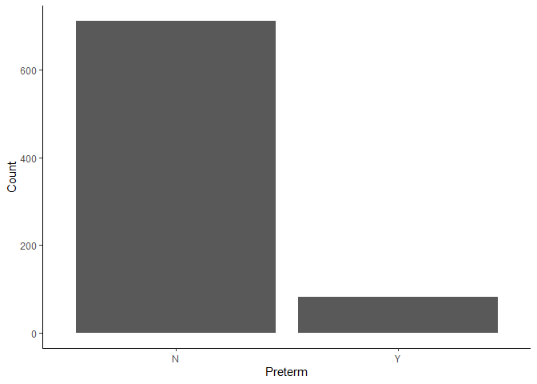

```r
ggplot(opt %>%
    drop_na(Preterm),
    aes(x=Preterm)
) + geom_bar() + theme_classic() + ylab('Count')
```

**Table 4.** Numerical summary of preterm birth

```r
kable(opt %>%
    group_by(Preterm) %>%
    summarize(Count=n()) %>%
    mutate(Percent=Count/sum(Count)*100) %>%
    adorn_totals()
)
```

| Preterm | Count | Percent |
| --- | --- | --- |
| N | 711 | 86.391251 |
| Y | 82 | 9.963548 |
| NA | 30 | 3.645201 |
| Total | 823 | 100.000000 |

### Maximum and minimum infant birthweight

As seen in Table 5, the maximum observed infant birthweight was 5160g, and the minimum birthweight was 450g. These values correspond to z-scores of 3.3 and -4.8, respectively. This means that the maximum birthweight was 3.3 standard deviations above the mean of 3248, while the minimum birthweight was 4.8 standard deviations below the mean. This further supports that the birthweight distribution is left-skewed, since the lowest observed value was more extreme than the highest observed value.

**Table 5.** Z-scores for maximum and minimum infant birthweight

```r
kable(opt %>%
    summarize(
        Min=min(Birthweight, na.rm=TRUE),
        Max=max(Birthweight, na.rm=TRUE),
        Mean=mean(Birthweight, na.rm=TRUE),
        SD=sd(Birthweight, na.rm=TRUE),
    ) %>%
    gather(' ', 'Value', Min, Max) %>%
    mutate(Z_Score=(Value-Mean)/SD) %>%
    subset(select=c(' ', 'Value', 'Z_Score'))
)
```

|  | Value | Z_Score |
| --- | --- | --- |
| Min | 450 | -4.824753 |
| Max | 5160 | 3.296137 |

### Relationship between preterm birth and treatment group

To analyze the relationship between preterm birth and treatment group, which are both categorical, it is most appropriate to consider the proportion of subjects in each group who had preterm births, which can be seen in Table 6. Since there were 38 preterm births in the control group of 391 total pregnant individuals, 9.7% of the control group had preterm births. Since there were 44 preterm births in the treatment group of total size 402, that means 10.9% of the treatment group had preterm births. Therefore, the treatment group had a rate of preterm births that was 1.2 percentage points higher than the control group.

I decided that this relationship would be best visualized using stacked bar charts of the group proportions, where each bar has a total of 100%. This is because the relative frequencies of preterm births within each group can be easily compared side-by-side, whereas if I had used a stacked or grouped bar chart of simple counts or proportions of the total sample, it would be harder to see the difference in preterm birth rates between the treatment groups, since the size of the treatment groups are slightly different.

**Figure 5.** Visualization of relationship between preterm birth and treatment group

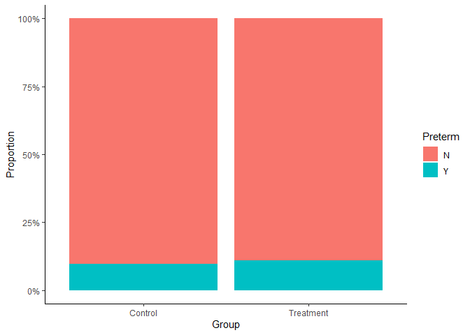

```r
ggplot(opt %>%
    drop_na(Preterm) %>%
    group_by(Group, Preterm) %>%
    summarize(Proportion=n(), .groups='drop'),
    aes(x=Group, y=Proportion, fill=Preterm)
) + geom_bar(stat='identity', position='fill') + theme_classic() + scale_y_continuous(labels=percent_format())
```

**Table 6.** Numerical summary of relationship between preterm birth and treatment group

```r
kable(opt %>%
    drop_na(Preterm) %>%
    group_by(Group, Preterm) %>%
    summarize(Count=n(), .groups='drop') %>%
    spread(key=Preterm, value=Count) %>%
    mutate(Total=Y+N) %>%
    mutate(Pct_N=N/Total*100, Pct_Y=Y/Total*100, Pct_Total=(N+Y)/Total*100)
)
```

| Group | N | Y | Total | Pct_N | Pct_Y | Pct_Total |
| --- | --- | --- | --- | --- | --- | --- |
| Control | 353 | 38 | 391 | 90.28133 | 9.71867 | 100 |
| Treatment | 358 | 44 | 402 | 89.05473 | 10.94527 | 100 |

### Relationship between preterm birth and age of pregnant individual

To understand the relationship between preterm birth, which is categorical, and the age of the pregnant individual, which is quantitative, we should look at differences in measures of center and spread of the distributions of age for each category. These measures for those with and without preterm births are shown numerically in Table 7.

Since it has been shown previously that the age distribution is right-skewed, the optimal measure of center is the median, since the mean will be biased by the high outliers. The median age of individuals who had preterm births was 27, compared with a median age of 25 for those that did not have preterm births. Therefore, the median age of those with preterm births was 2 years greater than those without preterm births. In addition, the IQR of the age of those who had preterm births was 8.75 compared with 7.5 for those who did not, which indicates a wider spread of the middle 50% of the age distribution by 1.25 years. These differences in median and IQR suggest that the distribution of age of those who have preterm births is both higher, and spans a wider range, then those who do not have preterm births.

To visualize these distributional differences, I decided to display side-by-side box plots in Figure 6, since this allows the medians and IQRs of the two distributions to be readily compared.

**Figure 6.** Visualization of relationship between preterm birth and age of pregnant individual

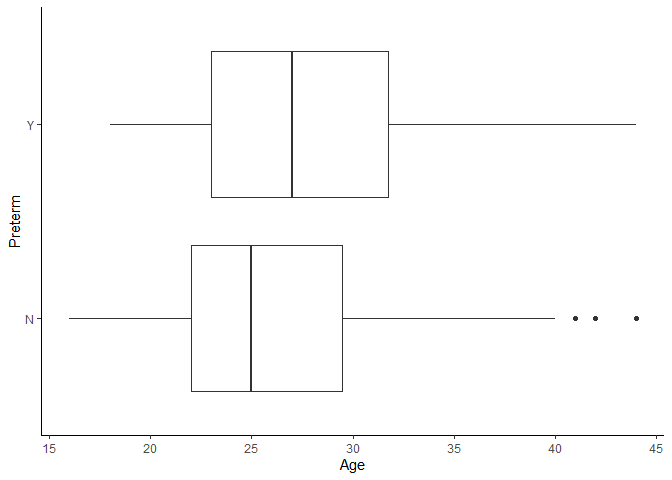

```r
ggplot(opt %>%
    drop_na(Preterm),
    aes(x=Age, y=Preterm)
) + geom_boxplot() + theme_classic()
```

**Table 7.** Numerical summary of relationship between preterm birth and age of pregnant individual

```r
kable(opt %>%
    drop_na(Preterm) %>%
    group_by(Preterm) %>%
    summarize(
        N=n(),
        Mean=mean(Age, na.rm=TRUE),
        SD=sd(Age, na.rm=TRUE),
        Min=min(Age, na.rm=TRUE),
        Pct_25=quantile(Age, 0.25, na.rm=TRUE),
        Median=median(Age, na.rm=TRUE),
        Pct_75=quantile(Age, 0.75, na.rm=TRUE),
        Max=max(Age, na.rm=TRUE),
        IQR=quantile(Age, 0.75, na.rm=TRUE)-quantile(Age, 0.25, na.rm=TRUE),
        Range=max(Age, na.rm=TRUE)-min(Age, na.rm=TRUE),
    )
)
```

| Preterm | N | Mean | SD | Min | Pct_25 | Median | Pct_75 | Max | IQR | Range |
| --- | --- | --- | --- | --- | --- | --- | --- | --- | --- | --- |
| N | 711 | 25.81997 | 5.494550 | 16 | 22 | 25 | 29.50 | 44 | 7.50 | 28 |
| Y | 82 | 27.54878 | 6.096249 | 18 | 23 | 27 | 31.75 | 44 | 8.75 | 26 |

### Relationship between age of pregnant individual and infant birthweight

The last relationship to analyze is between the age of the pregnant individual and the infant birthweight, which are both quantitative. Thus the relationship can be best visualized as a scatter plot, seen in Figure 7. Since there were many pregnant individuals with nearly the same age and infant birthweight, many of the points in the scatter plot overlap, making it diffuclt to see clear patterns. To better display the data, I decided to show the points with some tranparency, so that darkness provides an indication of the number of overlapping points. However, even this did not reveal a clear positive or negative assocation between the points, suggesting that there would be little correlation between the variables. To quantify this relationship, the actual correlation was computed and displayed in Table 8. The correlation between age and birthweight turned out to be just 0.04, indicating virtually no correlation.

**Figure 7.** Visualization of relationship between age of pregnant individual and infant birthweight

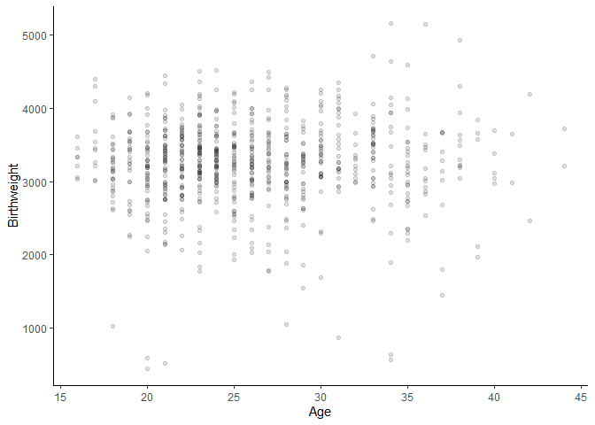

```r
ggplot(opt %>%
    drop_na(Preterm),
    aes(x=Age, y=Birthweight)
) + geom_point(alpha=1/8) + theme_classic()
```

**Table 8.** Numerical description of relationship between age of pregnant individual and infant birthweight

```r
kable(opt[c('Age', 'Birthweight')] %>%
    cor(use='complete.obs')
)
```

|  | Age | Birthweight |
| --- | --- | --- |
| Age | 1.0000000 | 0.0381046 |
| Birthweight | 0.0381046 | 1.0000000 |